# Analyze synteny of ORs (with start coordinates)

```r
library(circlize)
source("~/sciebo/librarySchrader.R")
library(rtracklayer)
```

#### Create a dataframe that contains

- orthology between ORs
- positions
- strand

From *segments.txt*: id mul geno list first last order 146 43 ACOL scaffold277 AcolOr003 AcolOr027 0 147 43 AECH scaffold192 AechOr002 AechOr027 1 148 43 AINS scaffold35 AinsOr014 AinsOr036 2 149 43 ACHA scaffold13 AchaOr011 AchaOr039 3 150 43 PARG scaffold103 PargOr002 PargOr016 4 151 43 AHEY scaffold15 AheyOr002 AheyOr155fdf 5

And then from *list_elements.txt* 4807 146 AcolOr003 0 + 4808 146 AcolOr004 4 + 4809 146 AcolOr005 5 + 4810 146 AcolOr006 6 + 4811 146 AcolOr007 7 + 4812 146 AcolOr008 8 + 4813 146 AcolOr009 9 + 4814 146 AcolOr010 10 + 4815 146 AcolOr011 11 + 4816 146 AcolOr012 12 + 4817 146 AcolOr013 13 + 4818 146 AcolOr014 14 + 4819 146 AcolOr015 15 + 4820 146 AcolOr017 16 + 4821 146 AcolOr019 17 + 4822 146 AcolOr021 19 + 4823 146 AcolOr023 20 + 4824 146 AcolOr024 22 + 4825 146 AcolOr025 23 + 4826 146 AcolOr027 25 +

And *multiplicons.txt* 38 ACOL scaffold277 AECH scaffold192 2 18 29 0 24 0 22 0 39 38 AINS scaffold35 3 29 38 0 28 0 23 0 40 39 ACHA scaffold13 4 25 42 0 37 0 22 0 41 40 PARG scaffold103 5 21 38 1 39 0 13 0 42 41 AHEY scaffold15 6 12 28 12 32 2 20 0 43 41 AHEY scaffold15 6 12 29 0 27 0 18 0 44 40 AHEY scaffold15 5 18 42 1 40 0 21 0

```r
# Load gffs
gff<-list()
file.names <- dir("/Users/lukas/sciebo/inquilineGenomics18/ORevolution/results/annotations/", pattern =".gff3")
for (i in file.names){
  gff[[i]]<-readGFF(paste("/Users/lukas/sciebo/inquilineGenomics18/ORevolution/results/annotations/",i,sep=""))
}
gffs<-do.call("rbind", gff)
gene<-subset(gffs,type=="gene")
gene$ID<-gsub("-","",gene$ID)
# Load segments.txt
segments<-read.csv("/Users/lukas/sciebo/inquilineGenomics18/synteny/ORs/output.multiple3/segments.txt",sep="\t")
#load list_elements.txt
list_elements<-read.csv("/Users/lukas/sciebo/inquilineGenomics18/synteny/ORs/output.multiple3/list_elements.txt",sep="\t")
#-------------------------------
# Select which segment to analyze
#-------------------------------
selectedSegment<-6
# retrieve appropriate list_elements
x<-subset(list_elements,segment>=min(subset(segments,multiplicon==selectedSegment,id)) & segment<=max(subset(segments,multiplicon==selectedSegment,id)))
x$species<-as.factor(gsub("(....).*","\\1",x$gene,perl=T))
#x$y<-4
# load all orthogroups to determine orthology
orthogroups<-read.csv("/Users/lukas/sciebo/inquilineGenomics18/synteny/ORs/Orthologues.list",sep="\t",F)
colnames(orthogroups)<-c("gene","OG")
x<-merge(x,orthogroups,by.x="gene",by.y="gene")
x$OG<-as.factor(as.character(x$OG))
# create color column
library(RColorBrewer)
n <- length(levels(x$OG))
qual_col_pals = brewer.pal.info[brewer.pal.info$category == 'qual',]
col_vector = unlist(mapply(brewer.pal, qual_col_pals$maxcolors, rownames(qual_col_pals)))
x$cols<-col_vector[as.numeric(x$OG)]
# final dataset
x<-merge(x,gene,by.x="gene",by.y="ID")
```

```r
par(mar=rep(0,4))
circos.par("track.height" = 0.1,canvas.xlim=c(-1,1),canvas.ylim=c(-1.2,1.2))
circos.initialize(factors = x$species, x = x$start)
#circos.initialize(factors = rep(levels(x$species),2), x = c(rep(-2,length(levels(x$species))),rep(max(x$start)+2,length(levels(x$species)))))
circos.track(factors = rep(levels(x$species),2), y = c(rep(1,length(levels(x$species))),rep(28,length(levels(x$species)))),
    panel.fun = function(x, y) {
        circos.text(CELL_META$xcenter, CELL_META$cell.ylim[2] + uy(5, "mm"),
            CELL_META$sector.index)
        circos.axis(labels.cex = 0.6)
})
```

[figure not shown]

```r
#circos.trackPoints(x$species, x$start, x$y, col = col_vector[as.numeric(x$OG)], pch = 16, cex = 1)
#circos.text(-1, 0.5, "text", sector.index = "Parg", track.index = 1)
#circos.segments(1, 2, 3, 3,lwd=10,sector.index = "Parg")
for(i in levels(x$species)){
  #circos.rect(xleft = 1:max(x$start)-.3,xright=1:max(x$start)+.3,ybottom = 1, sector.index = i,ytop = 27,lwd=0.2)
  circos.rect(xleft = unlist(subset(x,species==i,start))-.3,xright = unlist(subset(x,species==i,start))+.3,ybottom = 1, ytop = 27,sector.index = i,col=unlist(subset(x,species==i,cols)),lwd=0.5,border=unlist(subset(x,species==i,cols)))

}
for(q in levels(x$OG)){

  tmp<-subset(x,OG==q)
  if(nrow(tmp)>=2)
  for(i in 1:nrow(tmp)){
    for (p in 1:nrow(tmp)){
      if(p==i){next }
    alphasetting<-ifelse(abs(p-i)==1|abs(p-i)==5,3,500)
      circos.link(sector.index1 = tmp$species[i],point1 =  tmp$start[i], sector.index2 = tmp$species[p], point2 = tmp$start[p], h = 4,col=addalpha(unique(tmp$cols),1/alphasetting),lwd=3)


    }
  }
}
```

```r
#circos.link("Ahey", subset(x,OG=="OG0000136" & species=="Ahey",position), "Acha", subset(x,OG=="OG0000136" & species=="Acha",position), h = 0.4,col)
#plot(1,1,pch=19,col=tmp$cols[1])
```

[output not shown]

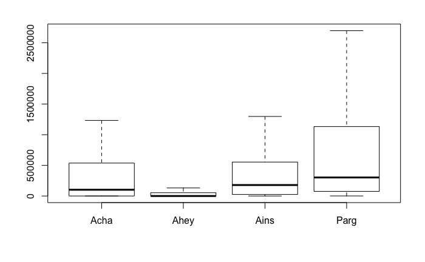

```r
fai<-list()
file.names <- dir(Sys.glob("/Users/lukas/sciebo/inquilineGenomics18/inquilines_v2.1/*/genome/"), pattern =".fai",full.names = T)
file.names <- c(file.names,dir(Sys.glob("~/sciebo/inquilineGenomics18/reannotations_of_7_ants/*/genome/"), pattern =".fai",full.names = T))
for (i in file.names){
  fai[[i]]<-read.csv(i,sep="\t",F)
}
names(fai)<-gsub(".*/","",file.names) %>% gsub("\\..*","",.) %>% gsub("(.).*\\_(...).*","\\1\\2",.,perl=T)
names(gff)<-substr(names(gff),1,4)
a<-list()
maxOR<-list()
minOR<-list()
b<-list()
d<-list()
for(i in names(fai)){
a[[i]]<-split(gff[[i]],f = gff[[i]]$seqid)
maxOR[[i]]<-data.frame(unlist(lapply(a[[i]],function(x) max(c(x$start,x$end)))))
minOR[[i]]<-data.frame(unlist(lapply(a[[i]],function(x) min(c(x$start,x$end)))))
colnames(maxOR[[i]])<-"maxPos"
colnames(minOR[[i]])<-"minPos"
b[[i]]<-merge(fai[[i]],maxOR[[i]],by.x="V1",by.y="row.names",all.y=T)
b[[i]]<-merge(b[[i]],minOR[[i]],by.x="V1",by.y="row.names",all.y=T)
}
#a2<-split(gff[[5]],f = gff[[5]]$seqid)
#maxOR2<-data.frame(unlist(lapply(a2,function(x) max(c(x$start,x$end)))))
#colnames(maxOR2)<-"maxPos"
#b2<-merge(Ahey,maxOR2,by.x="V1",by.y="row.names")
all<-lapply(b,function(x) cbind(x,x$maxPos/x$V2,x$minPos/x$V2))
for (i in 1:length(all)){
  colnames(all[[i]])<-c("scf","length","tmp1","tmp2","tmp3","maxORpos","minORpos","relMaxOR","relMinOR")
  }
boxplot(b[[1]]$V2-b[[1]]$maxPos,b[[2]]$V2-b[[2]]$maxPos,b[[3]]$V2-b[[3]]$maxPos,b[[4]]$V2-b[[4]]$maxPos,outline=F,names=c("Acha","Ahey","Ains","Parg"))
```

### Distribution of minimal (blue) and maximum (orange) relative annotation starts across all scaffolds for the different genomes.

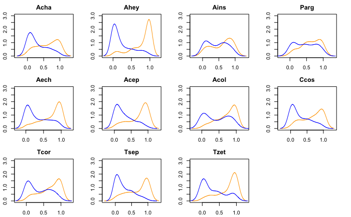

```r
par(mai=rep(.3,4))
par(mfrow=c(3,4))
for(i in 1:length(all)){
plot(density(c(all[[i]]$relMaxOR)),main=names(all)[i],xlab="",col="orange",ylim=c(0,3))
points(density(c(all[[i]]$relMinOR)),main=names(all)[i],xlab="",type="l",col="blue")
}
```